# Springboard Foundations of Data Science - Milestone Report

Susan Joseph

November 5, 2017

## Structure of the Customer and Product files

```
## 'data.frame':    1183036 obs. of  24 variables:
##  $ ncodpers             : int  1000013 1000013 1000013 1000013 1000013 1000013 1000013 1000013 1000013 1000013 ...
##  $ fecha_dato           : chr  "2015-01-28" "2015-02-28" "2015-03-28" "2015-04-28" ...
##  $ ind_empleado         : chr  "N" "N" "N" "N" ...
##  $ pais_residencia      : chr  "ES" "ES" "ES" "ES" ...
##  $ sexo                 : chr  "V" "V" "V" "V" ...
##  $ age                  : chr  "23" "23" "23" "23" ...
##  $ fecha_alta           : chr  "2011-12-29" "2011-12-29" "2011-12-29" "2011-12-29" ...
##  $ ind_nuevo            : chr  "0" "0" "0" "0" ...
##  $ antiguedad           : chr  "43" "43" "43" "43" ...
##  $ indrel               : chr  "1" "1" "1" "1" ...
##  $ ult_fec_cli_1t       : chr  NA NA NA NA ...
##  $ indrel_1mes          : chr  "1.0" "1.0" "1.0" "1.0" ...
##  $ tiprel_1mes          : chr  "A" "A" "A" "A" ...
##  $ indresi              : chr  "S" "S" "S" "S" ...
##  $ indext               : chr  "N" "N" "N" "N" ...
##  $ conyuemp             : chr  NA NA NA NA ...
##  $ canal_entrada        : chr  "KHE" "KHE" "KHE" "KHE" ...
##  $ indfall              : chr  "N" "N" "N" "N" ...
##  $ tipodom              : chr  "1" "1" "1" "1" ...
##  $ cod_prov             : chr  "52" "52" "52" "52" ...
##  $ nomprov              : chr  "MELILLA" "MELILLA" "MELILLA" "MELILLA" ...
##  $ ind_actividad_cliente: chr  "1" "1" "1" "1" ...
##  $ renta                : num  108623 108623 108623 108623 108623 ...
##  $ segmento             : chr  "03 - UNIVERSITARIO" "03 - UNIVERSITARIO" "03 - UNIVERSITARIO" "03 - UNIVERSITARIO" ...
```

```
## 'data.frame':    1183036 obs. of  26 variables:
##  $ ncodpers         : int  1000013 1000013 1000013 1000013 1000013 1000013 1000013 1000013 1000013 1000013 ...
##  $ fecha_dato       : chr  "2015-01-28" "2015-02-28" "2015-03-28" "2015-04-28" ...
##  $ ind_ahor_fin_ult1: int  0 0 0 0 0 0 0 0 0 0 ...
##  $ ind_aval_fin_ult1: int  0 0 0 0 0 0 0 0 0 0 ...
##  $ ind_cco_fin_ult1 : int  1 1 1 1 1 1 1 1 1 1 ...
##  $ ind_cder_fin_ult1: int  0 0 0 0 0 0 0 0 0 0 ...
##  $ ind_cno_fin_ult1 : int  0 0 0 0 0 0 0 0 0 0 ...
##  $ ind_ctju_fin_ult1: int  0 0 0 0 0 0 0 0 0 0 ...
##  $ ind_ctma_fin_ult1: int  0 0 0 0 0 0 0 0 0 0 ...
##  $ ind_ctop_fin_ult1: int  0 0 0 0 0 0 0 0 0 0 ...
##  $ ind_ctpp_fin_ult1: int  0 0 0 0 0 0 0 0 0 0 ...
##  $ ind_deco_fin_ult1: int  0 0 0 0 0 0 0 0 0 0 ...
##  $ ind_deme_fin_ult1: int  0 0 0 0 0 0 0 0 0 0 ...
##  $ ind_dela_fin_ult1: int  0 0 0 0 0 0 0 0 0 0 ...
##  $ ind_ecue_fin_ult1: int  0 0 0 0 0 0 0 0 0 0 ...
##  $ ind_fond_fin_ult1: int  0 0 0 0 0 0 0 0 0 0 ...
##  $ ind_hip_fin_ult1 : int  0 0 0 0 0 0 0 0 0 0 ...
##  $ ind_plan_fin_ult1: int  0 0 0 0 0 0 0 0 0 0 ...
##  $ ind_pres_fin_ult1: int  0 0 0 0 0 0 0 0 0 0 ...
##  $ ind_reca_fin_ult1: int  0 0 0 0 0 0 0 0 0 0 ...
##  $ ind_tjcr_fin_ult1: int  0 0 0 0 0 0 0 0 0 0 ...
##  $ ind_valo_fin_ult1: int  0 0 0 0 0 0 0 0 0 0 ...
##  $ ind_viv_fin_ult1 : int  0 0 0 0 0 0 0 0 0 0 ...
##  $ ind_nomina_ult1  : chr  "0" "0" "0" "0" ...
##  $ ind_nom_pens_ult1: chr  "0" "0" "0" "0" ...
##  $ ind_recibo_ult1  : int  0 0 0 0 0 0 0 0 0 0 ...
```

## Converting the variables to the correct data types

## Data Wrangling

### There are 17 rows for one Customer where every row is a month of data of a customer. The below ouput displays the number of rows for each customer

```
## # A tibble: 78,359 x 2
## # Groups:   n [17]
##    ncodpers     n
##       <int> <int>
##  1    15895    17
##  2    15918    17
##  3    15937    17
##  4    15941    17
##  5    15952    17
##  6    15957    17
##  7    15964    17
##  8    15969    17
##  9    15976    17
## 10    15997    17
## # ... with 78,349 more rows
```

### Summarizing the rows so there is only one row per customer and eliminating columns that do not add value to the analysis. There are ###78,359 customers after the summarization

### Replacing the column canal_entrada with ‘Other’ values where count of observations is less than 200

### Hence all the categories have more than 200 elements

```
##
##   KAA   KAB   KAE   KAG   KAS   KAT   KAY   KBZ   KCC   KEY   KFA   KFC
##   233   300   208   305   444 16112   355   241   206   241  1836 14556
##   KHD   KHE   KHK   KHL   KHM   KHN OTHER   RED
##   540 23189  1728   346   399   406  2104   477
```

### Finding out the number of NA’s by column

```
##              ncodpers          ind_empleado       pais_residencia
##                     0                   514                   514
##                  sexo                   age            fecha_alta
##                   515                   514                   514
##            antiguedad                indrel           indrel_1mes
##                     0                     0                   735
##           tiprel_1mes               indresi                indext
##                   735                   514                   514
## ind_actividad_cliente                 renta              segmento
##                     0                 20830                   807
##   canal_entrada_clean
##                 14133
```

### Impute NA’s for each column

```
##
##     H     V
## 35956 41888
```

#### renta: This one is complicated because about 20% of the values are missing, however for the sake of simplicity we will do

#### the easiest solution and take the median of the values

```
##
##           01 - TOP  02 - PARTICULARES 03 - UNIVERSITARIO
##               3675              40240              33637
```

```
##
##   KAA   KAB   KAE   KAG   KAS   KAT   KAY   KBZ   KCC   KEY   KFA   KFC
##   233   300   208   305   444 16112   355   241   206   241  1836 14556
##   KHD   KHE   KHK   KHL   KHM   KHN OTHER   RED
##   540 23189  1728   346   399   406  2104   477
```

#### ind_empleado: Since most of the Employee Index values are of type ‘N’(Not employee) we will assume that the 514 missing entries are #### also of type ‘N’

```
##
##     A     B     F     N
##    20    12    20 77793
```

#### pais_residencia: Since most of the Employees are from Spain (ES) we will assume that the 514 missing entries are also from the country #### Spain

```
##
##    AD    AE    AR    AU    BE    BG    BO    BR    CA    CD    CH    CL
##     1     3    26     1     8     2     3     6     3     1    12     4
##    CM    CN    CO    CR    CU    DE    DO    DZ    EC    ES    FI    FR
##     2     3    17     1     3    24     1     2     5 77575     1    33
##    GB    GI    GR    GT    HU    IE    IL    IT    JP    KE    MX    NG
##    17     1     2     1     1     1     2     9     1     1     4     1
##    NI    NL    NO    PE    PK    PL    PT    PY    RO    RU    SE    SG
##     1     4     2     3     1     6     3     1    10     3     2     2
##    TG    TH    TR    TW    UA    US    UY    VE    ZA
##     1     2     1     1     2    13     2     6     1
```

#### indrel_lmes: Since most of the Customer type is 1.0 we will assume that the 735 missing entries are also of the same Customer type

```
##
##     1   1.0     2   2.0     3   3.0     4     P
## 27499 50101     1     2     8     6     1     6
```

#### tiprel_lmes: Since most of the Customer relation is of type ‘A’(Active) we will assume that the 735 missing entries are also of the ####same Customer relation type

```
##
##     A     I     P     R
## 41830 35773    15     6
```

#### age: Since most of the Customers are of age 23 we will assume that the 514 missing entries are also of the same age

```
##
##    2    3    4    5    6    7    8    9   10   11   12   13   14   15   16
##   10   17   17   21   26   24   26   20   19   29   22   67   71   86   76
##   17   18   19   20   21   22   23   24   25   26   27   28   29   30   31
##   71   57   65 2453 5006 5322 5791 4669 2883 2189 1761 1464 1265 1136 1102
##   32   33   34   35   36   37   38   39   40   41   42   43   44   45   46
## 1051 1057  985  921 1005 1012 1052 1184 1383 1572 1609 1688 1665 1636 1537
##   47   48   49   50   51   52   53   54   55   56   57   58   59   60   61
## 1415 1522 1340 1293 1133 1082 1028  989  840  774  744  659  623  605  595
##   62   63   64   65   66   67   68   69   70   71   72   73   74   75   76
##  490  475  399  390  388  402  378  374  393  295  298  294  306  291  226
##   77   78   79   80   81   82   83   84   85   86   87   88   89   90   91
##  251  210  158  202  200  210  157  142  133  128  109  101  104   88   86
##   92   93   94   95   96   97   98   99  100  101  102  103  104  105  106
##   65   61   57   45   44   25   17    9   13   14   11   12    7    7    3
##  107  108  109  111  112  113  116  117
##    3    2    1    1    1    1    3    1
```

#### indresi: Since most of the Customers are residents of Spain with a resident index of ‘S’ we will assume that the 514 missing entries are ####also residents

```
##
##     N     S
##   270 77575
```

#### fecha_alta: This one was a tough one but since there were 15 rows for 1995-10-27 we will assume that the 514 missing entries are also in ####that year and month when the customer became the first holder of a contract in the bank.

#### indext: Since most of the customers are born in Spain and is the same as the bank country the foreigner index is ‘N’ and the missing 514 ####entries are also ‘N’

```
##
##     N     S
## 74546  3299
```

### Finally all the columns are zeroes as all the NA’s in all the columns were imputed and replaced

```
##              ncodpers          ind_empleado       pais_residencia
##                     0                     0                     0
##                  sexo                   age            fecha_alta
##                     0                     0                     0
##            antiguedad                indrel           indrel_1mes
##                     0                     0                     0
##           tiprel_1mes               indresi                indext
##                     0                     0                     0
## ind_actividad_cliente                 renta              segmento
##                     0                     0                     0
##   canal_entrada_clean
##                     0
```

## Descriptive and Exploratory Analysis

#### The number of males are more than females at 42,403

```
##
##     H     V
## 35956 42403
```

#### The percentage of males are more than females at 54.12%

```
##
##      H      V
## 45.886 54.114
```

#### Plotting the sex in a Histogram shows that the count of males are more than females

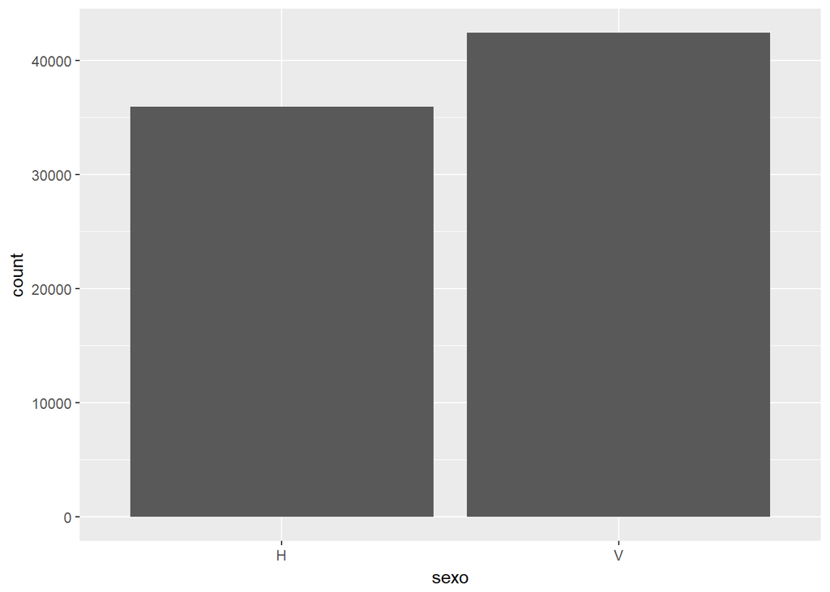

#### Age: The minumum age of the customer is 2 and maximum is 117. The mean or average age of the customer is around 38 years and the

#### standard deviation is only 16.98 which means they are closer to the mean age.

```
##    Min. 1st Qu.  Median    Mean 3rd Qu.    Max.
##    2.00   23.00   34.00   38.27   49.00  117.00
```

```
## [1] 38.26867
```

```
## [1] 16.98392
```

```
## [1] 34
```

```
## [1] 2
```

```
## [1] 117
```

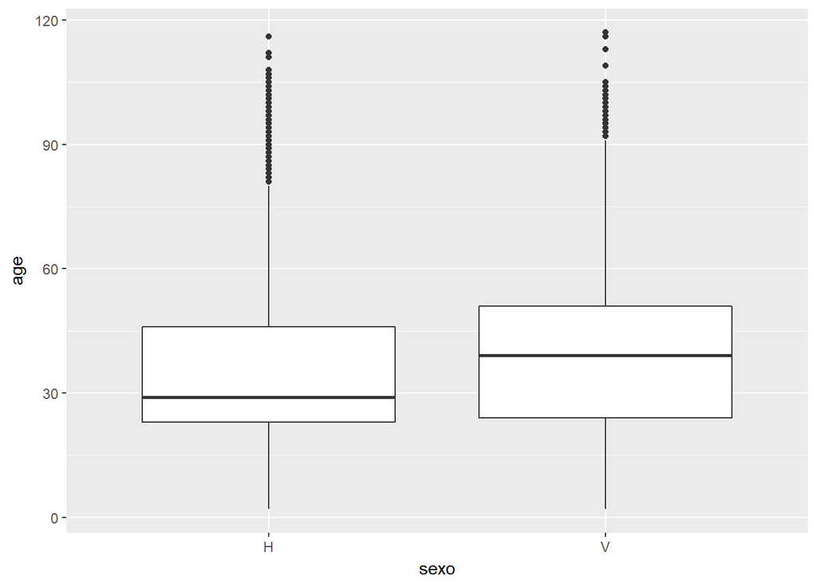

#### Channel: Customer use KHE Channel the most with a total of 37,322 and account for 47.63% of the total

```
##
##   KAA   KAB   KAE   KAG   KAS   KAT   KAY   KBZ   KCC   KEY   KFA   KFC
##   233   300   208   305   444 16112   355   241   206   241  1836 14556
##   KHD   KHE   KHK   KHL   KHM   KHN OTHER   RED
##   540 37322  1728   346   399   406  2104   477
```

```
##
##    KAA    KAB    KAE    KAG    KAS    KAT    KAY    KBZ    KCC    KEY
##  0.297  0.383  0.265  0.389  0.567 20.562  0.453  0.308  0.263  0.308
##    KFA    KFC    KHD    KHE    KHK    KHL    KHM    KHN  OTHER    RED
##  2.343 18.576  0.689 47.630  2.205  0.442  0.509  0.518  2.685  0.609
```

#### Gross income of household: The mean income is 121,388 . The minimum salary of the Customers is 5341 and the maximum salary is

#### 15,711,716

```
##     Min.  1st Qu.   Median     Mean  3rd Qu.     Max.
##     5341    78302    99710   121388   127805 15711716
```

```
## [1] 121387.8
```

```
## [1] 149805.6
```

```
## [1] 99710.07
```

```
## [1] 5340.93
```

```
## [1] 15711716
```

#### Customer Segmentation: The highest segment of customers are 02 - PARTICULARES(Individuals) with 41047 and accounting for 52.38% as

#### shown by the bar graph

```
##
##           01 - TOP  02 - PARTICULARES 03 - UNIVERSITARIO
##               3675              41047              33637
```

```
##
##           01 - TOP  02 - PARTICULARES 03 - UNIVERSITARIO
##              4.690             52.383             42.927
```

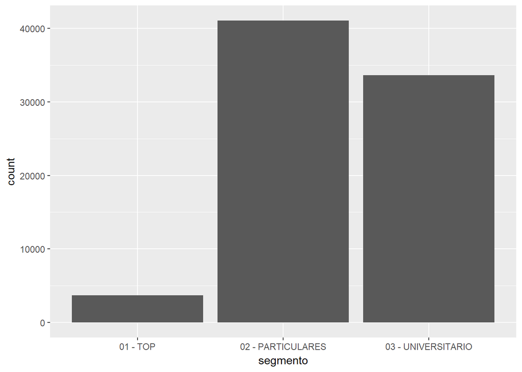